# Climate Change and Logical Fallacies

Critical Thinking and Climate Change Implications

EA30, Pomona College

Nov. 2017

## EPA Adminstrator and Logical Fallacies

According the the Washington Post, Scott Pruitt, Trump’s EPA adminstrator told an audience at the Heritage Foundation, “What’s most important at the agency is to have scientific advisers that are objective, independent-minded, providing transparent recommendations” (Dennis 2017). By having EPA science advisors who also receive funding from the agency causes Pruitt to question “the independence and the veracity and the transparency” of the recommendations made by these individuals.

Dennis, Brady. 2017. “Scott Pruitt Suggests He Will Restrict Scientists Who Get Epa Grants from Advising the Agency.” *Washington Post*, October. Washington Post. https://www.washingtonpost.com/news/energy-environment/wp/2017/10/17/scott-pruitt-suggests-he-will-restrict-scientists-who-get-epa-grants-from-advising-the-agency/?utm_term=.9b1b4a114b1e.

Apparently, Pruitt’s concern objectivity in science. While this is a concern all scientists share, his claim that scientists that recieve EPA funding impedes objectivity. Let’s unpack his assumptions here and determine if there is a logical fallacy…

First, what EPA panels is Pruitt refering to? I was able to find 13 advsisory panels:

- EPA Board of Scientific Counselors
- Federal Insecticide, Fungicide, and Rodenticide Act Scientific Advisory Panel
- Science Advsisor Board – Chemical Assessment Advisory Committee
- Science Advsisor Board – Drinking Water Committee
- Science Advsisor Board – Ecological Processes and Effects Committee
- Science Advsisor Board – Environmental Economics Advisory Committee
- Science Advsisor Board – Environmental Engineering Committee
- Science Advsisor Board – Radiation Advisory Committee
- Economy-wide Modeling of the Benefits and Costs of Environmental Regulation
- IRIS Assessment for Ethyl Tertiary Butyl Ether
- IRIS Assessment for tert-Butyl Alcohol
- Scoping and Approach for Revising Guidelines for Devising Numerical Water Quality Criteria to Protect Aquatic Life
- Screening Methodologies to Support Risk and Technology Reviews: A Case Study Analysis

### Independence

Independence is often articulated as value when thinking about the scientific process. There are two ways we can think about scientific indendence. First, that the results and conclusions are not influenced by forces outside the experimental or procedural methods. Second, that funding of the sciences does not influece the outcomes of the science.

Pruitt’s argument might stem from a criticism that scientist are lemmings and willing to do research to support specific finacial incentives (funding sources with particular goals). That scientists are willing to sacrafice their scientific integrity to pursue these funding opportunities (so they can be rewarded, e.g. money to the universities, and publications for promotion…).

One question my students asked it’s more of a question of who is ultimately tapped – you could replace with more or less indendent, then we need to have to measure independence.

First, university faculty are paid by the university, although research grants might augment their salaries, they remain univerisyt employess. It’s pretty independent.

### Veracity

The question of varacity questions panels ability to conform to the facts. Of course, the irony that Pruitt’s boss struggles with this more than most, we’ll try to focus on the validity of the the concern.

### Transparency

On of the key aspects in science is transparency. Transpareny in how a study was designed, how data was collected and analyzed. These form the central tennets of high quality scientific work.

## Carbon Dioxide as a Major Greenhouse Gas

Although a host of gases can trap heat, carbon dioxide or CO<sub>2</sub> is particularly important. CO<sub>2</sub> concentrations are relatively large compared to most greenhouse gases and have increased due land use changes and the combustion of fossil fuels. We even know how much of the CO<sub>2</sub> in the atmosphere has come from burning of fossil fuels.

Atmospheric CO<sub>2</sub> concentrations are measured in a continuous fashion from several locations around the world. The longest record is measured on the volcano Mauna Loa, Hawaii. Using these data, we can estimate how CO<sub>2</sub> concentrations have changed.

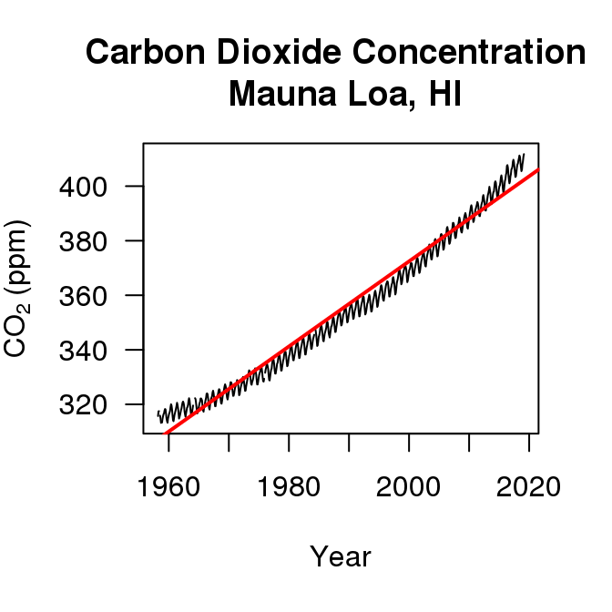

Observed CO<sub>2</sub> concentrations (black) have been steadily increasing since we have begun measuring them in the 1950s, with a best fit line (red). Note that the slope or the rate of change is also increasing.

[output not shown]